# Data analysis on Movies Dataset

#### by Deepak Das

The main aim of the project is to find insights about the datset containing information about particular movies. This project uses the movie dataset avaliable form Movie lens.This dataset contains just 1000 movies for analysis. We have used libraries present in Python such as Matplotlib,Seaborn,Pandas for reading and visualization of the dataset.

[figure not shown]

# We import the packages required for visualization

```python
import pandas as pd
import matplotlib.pyplot as plt
import seaborn as sns
%matplotlib inline
```

# Data description

The data is in csv format.In computing, a comma-separated values (CSV) file stores tabular data (numbers and text) in plain text. Each line of the file is a data record. Each record consists of one or more fields, separated by commas. Data are collected on 12 different informations of a movie,with rating being in the order of 1 (worst) and 10 (best) and the metascore being in the order from 1 (worst) and 100 (best).

```python
df = pd.read_csv('Documents//movie.csv')
```

# Attributes

- Rank
- Title
- Genre
- Description
- Director
- Actors
- Year
- Runtime
- Rating
- Votes
- Revenue
- Metascore

### Here we call the head function and print the first 5 rows of the data

```python
df.head()
```

|  | Rank | Title | Genre | Description | Director | Actors | Year | Runtime (Minutes) | Rating | Votes | Revenue (Millions) | Metascore |
| --- | --- | --- | --- | --- | --- | --- | --- | --- | --- | --- | --- | --- |
| 0 | 1 | Guardians of the Galaxy | Action,Adventure,Sci-Fi | A group of intergalactic criminals are forced ... | James Gunn | Chris Pratt, Vin Diesel, Bradley Cooper, Zoe S... | 2014 | 121 | 8.1 | 757074 | 333.13 | 76.0 |
| 1 | 2 | Prometheus | Adventure,Mystery,Sci-Fi | Following clues to the origin of mankind, a te... | Ridley Scott | Noomi Rapace, Logan Marshall-Green, Michael Fa... | 2012 | 124 | 7.0 | 485820 | 126.46 | 65.0 |
| 2 | 3 | Split | Horror,Thriller | Three girls are kidnapped by a man with a diag... | M. Night Shyamalan | James McAvoy, Anya Taylor-Joy, Haley Lu Richar... | 2016 | 117 | 7.3 | 157606 | 138.12 | 62.0 |
| 3 | 4 | Sing | Animation,Comedy,Family | In a city of humanoid animals, a hustling thea... | Christophe Lourdelet | Matthew McConaughey,Reese Witherspoon, Seth Ma... | 2016 | 108 | 7.2 | 60545 | 270.32 | 59.0 |
| 4 | 5 | Suicide Squad | Action,Adventure,Fantasy | A secret government agency recruits some of th... | David Ayer | Will Smith, Jared Leto, Margot Robbie, Viola D... | 2016 | 123 | 6.2 | 393727 | 325.02 | 40.0 |

### Here we see the total size of the dataset

```python
df.size
```

```
12000
```

### Here we see the shape of the dataset

```python
df.shape
```

```
(1000, 12)
```

### Here we see all the mathematical aspects of the data

```python
df.describe(include = 'all')
```

|  | Rank | Title | Genre | Description | Director | Actors | Year | Runtime (Minutes) | Rating | Votes | Revenue (Millions) | Metascore |
| --- | --- | --- | --- | --- | --- | --- | --- | --- | --- | --- | --- | --- |
| count | 1000.000000 | 1000 | 1000 | 1000 | 1000 | 1000 | 1000.000000 | 1000.000000 | 1000.000000 | 1.000000e+03 | 872.000000 | 936.000000 |
| unique | NaN | 999 | 207 | 1000 | 644 | 996 | NaN | NaN | NaN | NaN | NaN | NaN |
| top | NaN | The Host | Action,Adventure,Sci-Fi | Col. Katherine Powell, a military officer in c... | Ridley Scott | Shia LaBeouf, Megan Fox, Josh Duhamel, Tyrese ... | NaN | NaN | NaN | NaN | NaN | NaN |
| freq | NaN | 2 | 50 | 1 | 8 | 2 | NaN | NaN | NaN | NaN | NaN | NaN |
| mean | 500.500000 | NaN | NaN | NaN | NaN | NaN | 2012.783000 | 113.172000 | 6.723200 | 1.698083e+05 | 82.956376 | 58.985043 |
| std | 288.819436 | NaN | NaN | NaN | NaN | NaN | 3.205962 | 18.810908 | 0.945429 | 1.887626e+05 | 103.253540 | 17.194757 |
| min | 1.000000 | NaN | NaN | NaN | NaN | NaN | 2006.000000 | 66.000000 | 1.900000 | 6.100000e+01 | 0.000000 | 11.000000 |
| 25% | 250.750000 | NaN | NaN | NaN | NaN | NaN | 2010.000000 | 100.000000 | 6.200000 | 3.630900e+04 | 13.270000 | 47.000000 |
| 50% | 500.500000 | NaN | NaN | NaN | NaN | NaN | 2014.000000 | 111.000000 | 6.800000 | 1.107990e+05 | 47.985000 | 59.500000 |
| 75% | 750.250000 | NaN | NaN | NaN | NaN | NaN | 2016.000000 | 123.000000 | 7.400000 | 2.399098e+05 | 113.715000 | 72.000000 |
| max | 1000.000000 | NaN | NaN | NaN | NaN | NaN | 2016.000000 | 191.000000 | 9.000000 | 1.791916e+06 | 936.630000 | 100.000000 |

### We check for the missing values in the dataset

```python
df.isnull().sum()
```

```
Rank                    0
Title                   0
Genre                   0
Description             0
Director                0
Actors                  0
Year                    0
Runtime (Minutes)       0
Rating                  0
Votes                   0
Revenue (Millions)    128
Metascore              64
dtype: int64
```

#### We fill the null values with the mean values in the dataset

```python
df.mean()
```

```
Rank                     500.500000
Year                    2012.783000
Runtime (Minutes)        113.172000
Rating                     6.723200
Votes                 169808.255000
Revenue (Millions)        82.956376
Metascore                 58.985043
dtype: float64
```

#### Filling the Null values of the Revenue column with mean values

```python
df['Revenue (Millions)'] = df['Revenue (Millions)'].fillna(df['Revenue (Millions)'].mean())
```

#### Filling the Null values of the Metascore column with mean values

```python
df['Metascore'] = df['Metascore'].fillna(df['Metascore'].mean())
```

```python
df.isnull().sum()
```

```
Rank                  0
Title                 0
Genre                 0
Description           0
Director              0
Actors                0
Year                  0
Runtime (Minutes)     0
Rating                0
Votes                 0
Revenue (Millions)    0
Metascore             0
dtype: int64
```

### We drop the columns which are not required for analysis and for the Recommendation engine

```python
df1 = df.drop(columns = ['Description' ,'Director','Actors'])
df1.head()
```

|  | Rank | Title | Genre | Year | Runtime (Minutes) | Rating | Votes | Revenue (Millions) | Metascore |
| --- | --- | --- | --- | --- | --- | --- | --- | --- | --- |
| 0 | 1 | Guardians of the Galaxy | Action,Adventure,Sci-Fi | 2014 | 121 | 8.1 | 757074 | 333.13 | 76.0 |
| 1 | 2 | Prometheus | Adventure,Mystery,Sci-Fi | 2012 | 124 | 7.0 | 485820 | 126.46 | 65.0 |
| 2 | 3 | Split | Horror,Thriller | 2016 | 117 | 7.3 | 157606 | 138.12 | 62.0 |
| 3 | 4 | Sing | Animation,Comedy,Family | 2016 | 108 | 7.2 | 60545 | 270.32 | 59.0 |
| 4 | 5 | Suicide Squad | Action,Adventure,Fantasy | 2016 | 123 | 6.2 | 393727 | 325.02 | 40.0 |

# Exploratory Data Analysis

[figure not shown]

# Univariate Analysis

Univariate analysis is the simplest form of analyzing data. “Uni” means “one”, so in other words your data has only one variable. It doesn't deal with causes or relationships (unlike regression) and it's major purpose is to describe it takes data, summarizes that data and finds patterns in the data.The key pointers to the Univaraite analysis are to find out the outliers present in the data. We also tend to find the disitribution of the data on the dataset which can further help us for the Bivaraite/Multivariate analysis.

## Rating

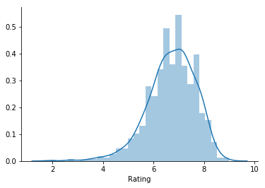

```python
x = df1['Rating']
sns.distplot(x)
sns.despine()
```

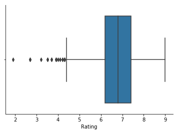

```python
sns.boxplot(df1['Rating'])
sns.despine()
```

### Inferences :-

- We observe that the plot is left skewed.
- There are almost no outliers present in the plot
- The ratings given are between 6-8 out of 10
- So the users have been generous with their ratings

## Runtime (Minutes)

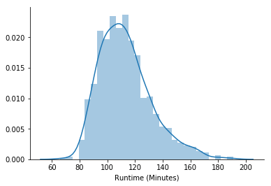

```python
x = df1['Runtime (Minutes)']
sns.distplot(x)
sns.despine()
```

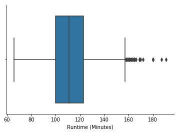

```python
sns.boxplot(df1['Runtime (Minutes)'])
sns.despine()
```

### Inferences :-

- The plot is little right-skewed
- Here also the number of outliers present are less
- The average runtime of movies is somewhere between 100-120 minutes
- Movies with a runtime of more than 140 minutes are quite less in number

## Metascore

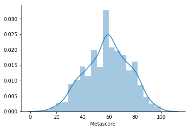

```python
x = df1['Metascore']
sns.distplot(x,);
```

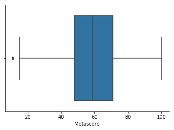

```python
sns.boxplot(df1['Metascore'])
sns.despine()
```

### Inferences :-

- The plot follows a normal distribution
- The outliers for the plot are almost negligible
- The average Metascore here is 60

# Bivariate Analysis

Bivariate analysis is the simultaneous analysis of two variables (attributes). It explores the concept of relationship between two variables, whether there exists an association and the strength of this association, or whether there are differences between two variables and the significance of these differences.

## Co-relation

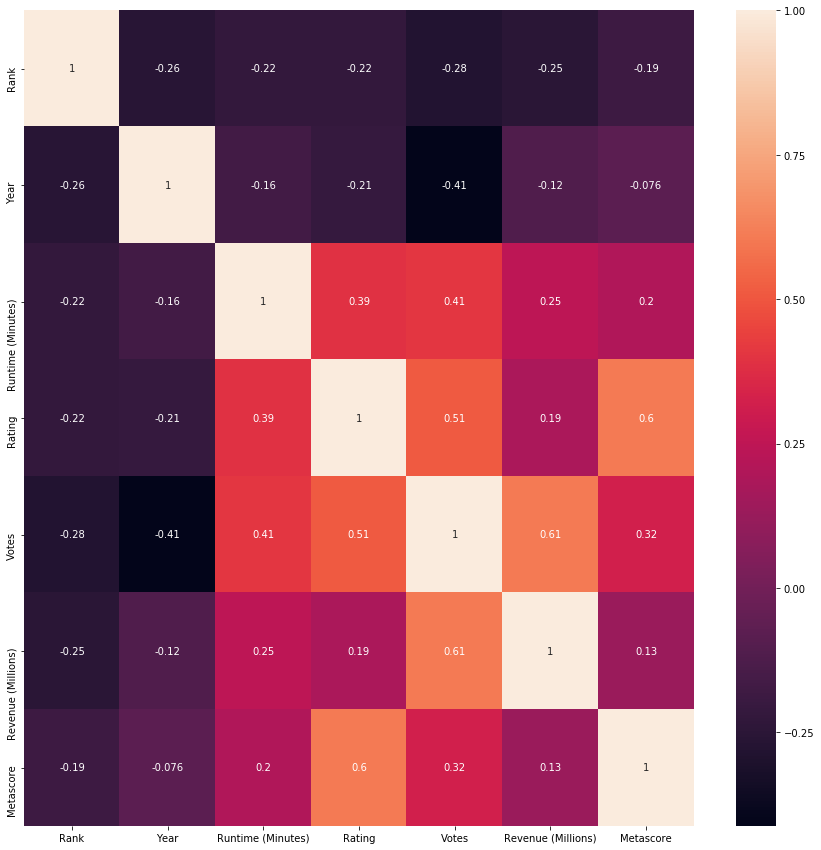

```python
plt.figure(figsize =(15,15))
sns.heatmap(df.corr(),annot=True)
plt.show()
```

## Year vs Rating

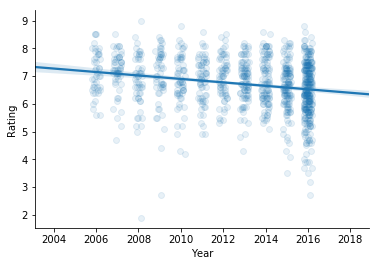

```python
sns.regplot(x = 'Year',y = 'Rating',data = df1 , x_jitter=0.2, scatter_kws={'alpha':0.1})
sns.despine()
```

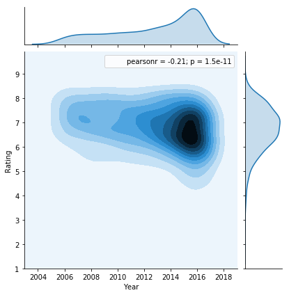

```python
sns.jointplot(x='Year', y='Rating', data=df1, kind="kde")
sns.despine()
```

### Inferences :-

- We observe a decreasing trend from the plot
- We have maximum data from the year 2016
- We can also say that as years passed by people became more conscious about watching movies because of the decrease in the ratings

## Year vs Metascore

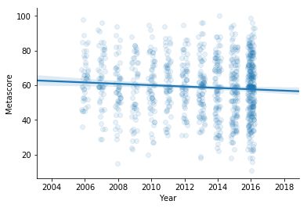

```python
sns.regplot(x = 'Year',y = 'Metascore',data = df1 , x_jitter=0.2, scatter_kws={'alpha':0.1})
sns.despine()
```

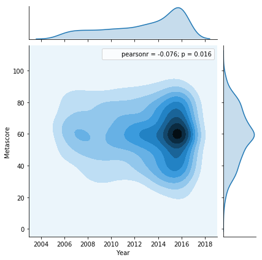

```python
sns.jointplot(x='Year', y='Metascore', data=df1, kind="kde")
sns.despine()
```

### Inferences :-

- Here also we can see that there is a slight decreasing trend
- Again the data for 2016 is maximum
- The critics have been a little generous over the years so there is a very slight decrease in the Metascore

## Year vs Runtime (Minutes)

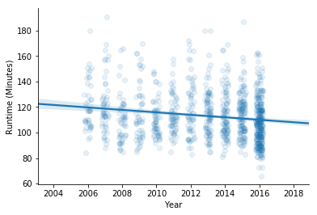

```python
sns.regplot(x = 'Year',y = 'Runtime (Minutes)',data = df1 , x_jitter=0.2, scatter_kws={'alpha':0.1})
sns.despine()
```

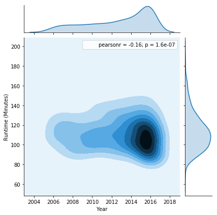

```python
sns.jointplot(x="Year", y='Runtime (Minutes)', data=df1, kind="kde")
sns.despine()
```

# Multi-Variate Analysis

Multivariate analysis (MVA) is based on the statistical principle of multivariate statistics, which involves observation and analysis of more than one statistical outcome variable at a time.

### Inferences from Runtime vs Rating in terms of Year

- From the plots below we can say that the dataset contains maximum number of movies from 2016 and over the years the runtime of movies has been around 100-125 minutes

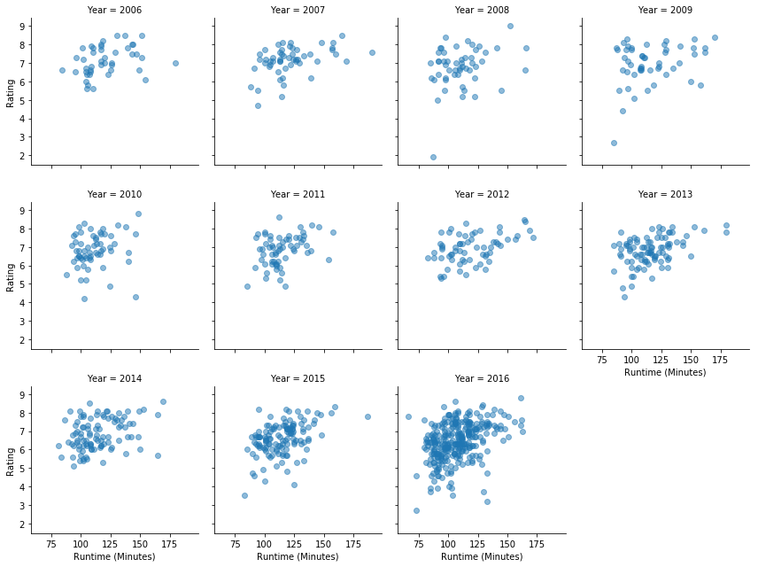

```python
grid = sns.FacetGrid(df1, col='Year',col_wrap = 4)
grid.map(plt.scatter,'Runtime (Minutes)','Rating',alpha = 0.5)
sns.despine()
```

# WordCloud

### What are Word Clouds?

Word clouds (also known as text clouds or tag clouds) work in a simple way: the more a specific word appears in a source of textual data (such as a speech, blog post, or database), the bigger and bolder it appears in the word cloud.

### We get to see the most common words used for a movie title in the dataset

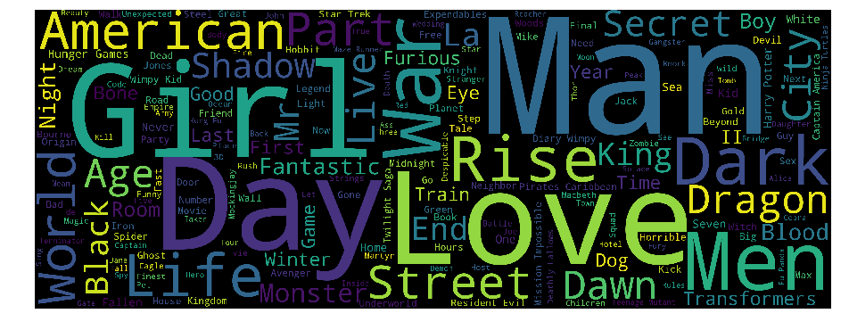

```python
import wordcloud
from wordcloud import WordCloud, STOPWORDS

# Create a wordcloud of the movie titles
df1['Title'] = df1['Title'].fillna("").astype('str')
title_corpus = ' '.join(df1['Title'])
title_wordcloud = WordCloud(stopwords=STOPWORDS,background_color='black', height=1500, width=4000).generate(title_corpus)

# Plot the wordcloud
plt.figure(figsize=(16,8))
plt.imshow(title_wordcloud)
plt.axis('off')
plt.show()
```

### We get to see the most common Genres of the Movie dataset

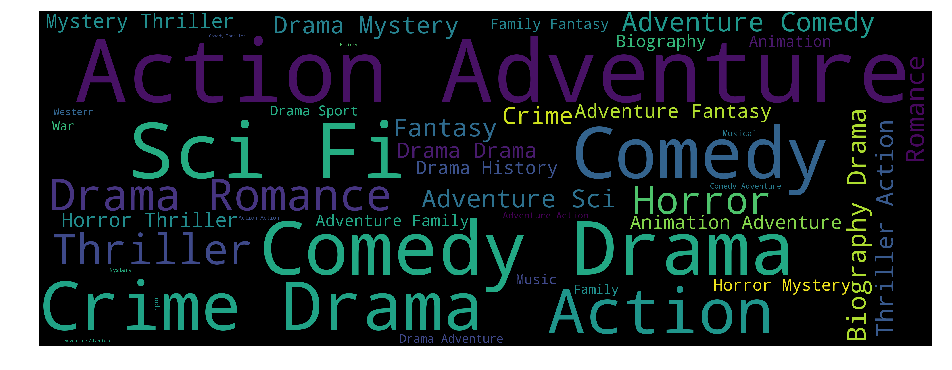

```python
# Create a wordcloud of the movie Genres
df['Genre'] = df1['Genre'].fillna("").astype('str')
title_corpus = ' '.join(df1['Genre'])
title_wordcloud = WordCloud(stopwords=STOPWORDS,background_color='black', height=1500, width=4000).generate(title_corpus)

# Plot the wordcloud
plt.figure(figsize=(16,8))
plt.imshow(title_wordcloud)
plt.axis('off')
plt.show()
```

# Recommendation Systems

[figure not shown]

# Content Based Recommendation

[figure not shown]

```python
from sklearn.feature_extraction.text import TfidfVectorizer
```

[figure not shown]

```python
tf = TfidfVectorizer()
tfidf_matrix = tf.fit_transform(df1['Genre'])
```

```python
print(tfidf_matrix.todense().shape)
```

```
(1000, 21)
```

```python
a = pd.DataFrame(tfidf_matrix.todense())
a
```

[output not shown]

1000 rows × 21 columns

```python
from sklearn.metrics.pairwise import cosine_similarity
```

[figure not shown]

### Building a matrix with cosine similarity scores

```python
cosine_sim = cosine_similarity(tfidf_matrix, tfidf_matrix)
print(cosine_sim)
```

```
[[1.         0.76815261 0.         ... 0.         0.30951647 0.        ]
 [0.76815261 1.         0.         ... 0.         0.28363342 0.        ]
 [0.         0.         1.         ... 0.         0.         0.        ]
 ...
 [0.         0.         0.         ... 1.         0.         0.        ]
 [0.30951647 0.28363342 0.         ... 0.         1.         0.28134523]
 [0.         0.         0.         ... 0.         0.28134523 1.        ]]
```

### Build a 1-dimensional array with movie titles

```python
titles = df1['Title']
indices = pd.Series(df.index, index=df1['Title'])
print(indices.head(10))
```

```
Title
Guardians of the Galaxy    0
Prometheus                 1
Split                      2
Sing                       3
Suicide Squad              4
The Great Wall             5
La La Land                 6
Mindhorn                   7
The Lost City of Z         8
Passengers                 9
dtype: int64
```

### Function that get movie recommendations based on the cosine similarity score of movie genres

```python
def genre_recommendations(title):
    sim_scores = list(enumerate(cosine_sim[indices[title]]))

    # Sorting the recommendation list according to cosine similarity
    sim_scores = sorted(sim_scores, key=lambda x: x[1], reverse=True)

    # Printing the top 30 recommendations in desencding order of similarity score
    sim_scores = sim_scores[1:30]

    # Indexing with Integer Location and returning the values
    movie_indices = [i[0] for i in sim_scores]
    return titles.iloc[movie_indices]
```

### Recommendation Based on the cosine simialrity and sorted according to similarity scores

```python
genre_recommendations('Guardians of the Galaxy')
```

```
12                               Rogue One
24            Independence Day: Resurgence
32                       X-Men: Apocalypse
35              Captain America: Civil War
48                        Star Trek Beyond
60      Batman v Superman: Dawn of Justice
67                      Mad Max: Fury Road
80                               Inception
85                          Jurassic World
94                 Avengers: Age of Ultron
126        Transformers: Age of Extinction
140                              Star Trek
156                            Pacific Rim
162             X-Men: Days of Future Past
195     Captain America: The First Avenger
200                       Edge of Tomorrow
203                               Iron Man
205                         X: First Class
212                           Transformers
216    Captain America: The Winter Soldier
220                         Hardcore Henry
227                              Predators
243                     Terminator Genisys
253               The Amazing Spider-Man 2
256                             Battleship
268               X-Men Origins: Wolverine
279                         Iron Man Three
287                      Jupiter Ascending
316                           The 5th Wave
Name: Title, dtype: object
```

# Summary

From the above given dataset we built a content based Recommendation system or Personalized recommendation system.First we had to clean the datset as there were some missing values then we had to drop the columns which didn't seem necessary for out Analysis. After that we did some Exploratory Data Analysis on the movie dataset and found some trends and observations from the plots.

Then we used the concept of TF-IDF vector to convert our texts into a matrix form and find the cosine similarity so that we can predict the similar movies present in the dataset. At last we were sucessfull in building a very small version of a personalized recommendation system.